# Custom Hierarchical One Factor

Haley Reed

6/23/2020

## Introduction

This document is meant to show the capabilities of the JAGS-practice.R script.

To understand pollster bias, we can use a Bayesian modeling to describe metric data as function of nominal predictors, similar to traditional ANOVA modeling. We will do so with using pollster data compiled by FiveThirtyEight. Here, we will explore how the specific pollster can act as an explanatory variable to predict bias present in individual polls.

It is of interest to include this nominal predictor of pollster because there is a historical precedent for bias due to systematic polling error and housing effects (Rakich 2019).

Because there are so many pollsters, for the sake of simplification, we will look at just the few pollsters with at least 30 in the 2008 for the General Presidential election.

Note: Positive Bias is bias towards the democratic party.

## Data Exploration

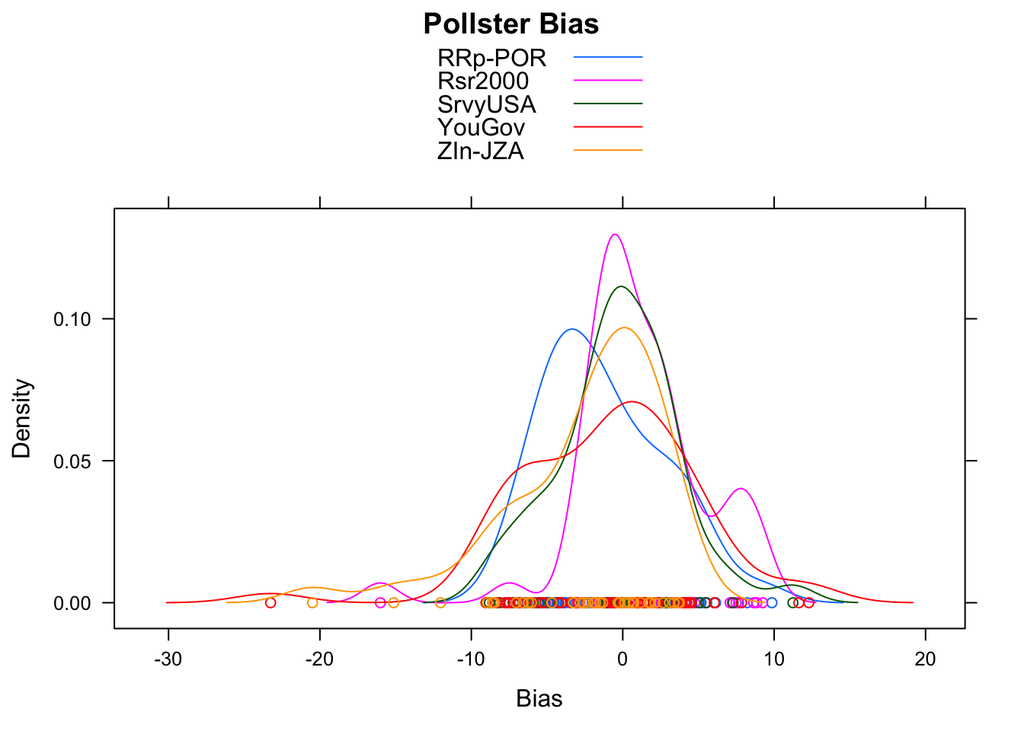

The analysis of distinguishing between pollsters seems valid based on this visualization because of the clear differences between individual pollsters seen below. The center, as well of the spread, of pollsters’ bias seems to vary greatly. Those patterns indicate that it would be helpful to build a model that uses pollsters as a nominal variable. In traditional statistics, this would mean ANOVA modeling, but we can answer the same questions of interest with a Bayesian model that closely imitates ANOVA models.

## The Model

The Bayesian hierarchical implemented here starts with generic noncommittal parameters. Specifically:

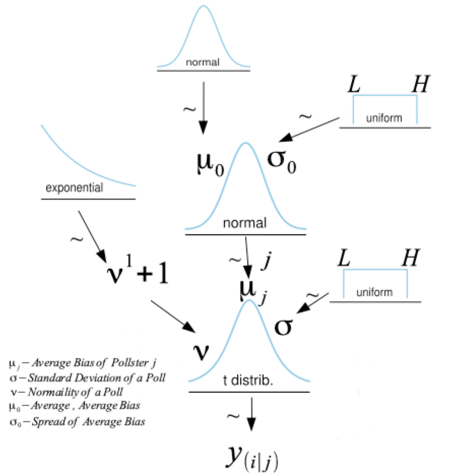

Model Diagram for this model.

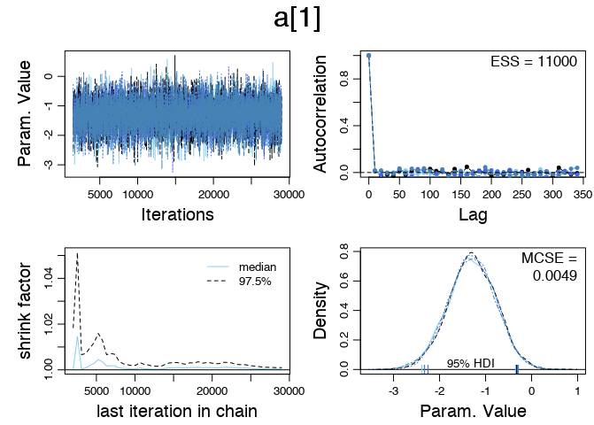

The density plots are sufficiently converged after the burn-in period, the autocorrelation appears small enough, and there is nothing in these plots that suggest it would not be safe to continue with the Bayesian analysis.

In this analysis, one of the main objectives is to find whether or not there is a difference of bias between pollsters. To do so, we must develop a reasonable ROPE for the difference between nominal groups. A difference of 1% bias is practically equivalent to zero, so the ROPE can be established as -1 to 1 for the purposes of this analysis.

Posterior distributions are shown below:

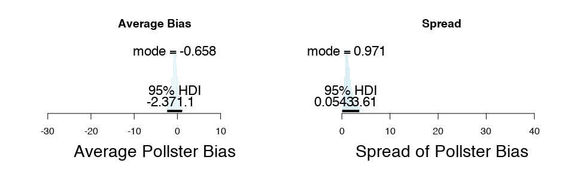

The most credible values and the highest density intervals for each parameter value can be seen below:

|  | Mean | Median | Mode | ESS | HDImass | HDIlow | HDIhigh |
| --- | --- | --- | --- | --- | --- | --- | --- |
| a[1] RRp-POR | -1.2969600 | -1.2964100 | -1.3328785 | 11000.0 | 0.95 | -2.3016800 | -0.293561 |
| a[2] Rsr2000 | 0.7223646 | 0.7175760 | 0.7106985 | 10026.5 | 0.95 | -0.5643040 | 1.976190 |
| a[3] SrvyUSA | -0.3750540 | -0.3871110 | -0.3340765 | 10531.4 | 0.95 | -1.4293100 | 0.804727 |
| a[4] YouGov | -0.8097338 | -0.7972155 | -0.7250317 | 11000.0 | 0.95 | -1.9596400 | 0.290272 |
| a[5] ZIn-JZA | -1.4016251 | -1.3739500 | -1.3591553 | 11687.2 | 0.95 | -2.7522400 | -0.131944 |
| ySigma | 3.9339265 | 3.9257250 | 3.9082818 | 9791.4 | 0.95 | 3.3724400 | 4.511320 |
| nuY | 7.7499590 | 6.7491600 | 5.4874295 | 7214.0 | 0.95 | 2.8732800 | 15.085100 |
| a0 | -0.6363593 | -0.6349225 | -0.5712504 | 11000.0 | 0.95 | -2.3466900 | 1.238460 |
| aSigma | 1.5733473 | 1.2727550 | 0.9555667 | 6298.1 | 0.95 | 0.0528095 | 3.676450 |

## Works Cited

Kruschke, John. 2010. *Doing Bayesian Data Analysis: A Tutorial with R, Jags, and Stan*. Academic Press.

Rakich, Nathaniel. 2019. “How to Read 2020 Polls Like a Fivethirtyeighter.” Edited by FiveThirtyEight. https://fivethirtyeight.com/features/how-to-read-2020-polls-like-a-fivethirtyeighter/.

Silver, Nate. 2020. “Raw Polls.” GitHub. https://github.com/fivethirtyeight/data/blob/master/pollster-ratings/raw-polls.csv.